# Algaritma K-Means

muhammad tahir nasrul laili - institut teknologi statitiska dan bisnis muhammadiyah

2023-01-18

# Algoritma K-Means

## Pengertian Algoritma K Means.

Clustering adalah teknik eksplorasi data yang digunakan untuk menemukan grup atau pola dalam himpunan data. Ada dua strategi pengelompokan standar: metode partisi dan pengelompokan hierarkis.Algoritma partisi yang paling terkenal dan umum digunakan termasuk: K-means clustering (MacQueen, 1967), di mana, setiap cluster diwakili oleh pusat atau sarana titik data milik cluster.

Ada beberapa pendekatan yang digunakan dalam mengembangkan metode clustering. Dua pendekatan utama adalah clustering dengan pendekatan partisi dan clustering dengan pendekatan hirarki. Clustering dengan pendekatan partisi atau sering disebut dengan partition-based clustering mengelompokkan data dengan memilah-milah data yang dianalisa ke dalam cluster-cluster yang ada. Clustering dengan pendekatan hirarki atau sering disebut dengan hierarchical clustering mengelompokkan data dengan membuat suatu hirarki berupa dendogram dimana data yang mirip akan ditempatkan pada hirarki yang berdekatan dan yang tidak pada hirarki yang berjauhan. Di samping kedua pendekatan tersebut, ada juga clustering dengan pendekatan automatic mapping (Self-Organising Map/SOM).

K-means merupakan salah satu pengelompokan data nonhierarki (sekatan) yang berusaha mempartisi data yang ada ke dalam bentuk dua atau lebih kelompok. Tujuan pengelompokan data ini adalah meminimalkan fungsi objektif yang diset dalam proses pengelompokan, yang berusaha meminimalkan variasi di dalam suatu kelompok dan memaksimalkan variasi antarkelompok.

Metode K-Means berusaha mengelompokkan data yang ada ke dalam beberapa kelompok, dimana data dalam satu kelompok mempunyai karakteristik yang sama satu sama lainnya dan mempunyai karakteristik yang berbeda dengan data yang ada di dalam kelompok yang lain.

# Tahapan Algoritma K-Means

1. Menyiapkan data.
2. Statistika dasar sebelum menerapkan K-Means.
3. Komputasikan k-means.
4. Visualisasikan.

# Eksperrimen Algoritma K-Means

## Library

1. Menyiapkan data

Untuk penerapan k-means menggunakan R, disini menggunakan dataset yang sudah tersedia di R yaitu mtcars dataset.

```r
data("mtcars")
mtcars <- na.omit(mtcars)

head(mtcars)
```

|  | mpg | cyl | disp | hp | drat | wt | qsec | vs | am | gear | carb |
| --- | --- | --- | --- | --- | --- | --- | --- | --- | --- | --- | --- |
| Mazda RX4 | 21.0 | 6 | 160 | 110 | 3.90 | 2.620 | 16.46 | 0 | 1 | 4 | 4 |
| Mazda RX4 Wag | 21.0 | 6 | 160 | 110 | 3.90 | 2.875 | 17.02 | 0 | 1 | 4 | 4 |
| Datsun 710 | 22.8 | 4 | 108 | 93 | 3.85 | 2.320 | 18.61 | 1 | 1 | 4 | 1 |
| Hornet 4 Drive | 21.4 | 6 | 258 | 110 | 3.08 | 3.215 | 19.44 | 1 | 0 | 3 | 1 |
| Hornet Sportabout | 18.7 | 8 | 360 | 175 | 3.15 | 3.440 | 17.02 | 0 | 0 | 3 | 2 |
| Valiant | 18.1 | 6 | 225 | 105 | 2.76 | 3.460 | 20.22 | 1 | 0 | 3 | 1 |

2. Statistika dasar sebelum menerapkan K-Means

Perhatikan bahwa variabel memiliki cara dan varians yang berbeda besar. Karena kita tidak ingin algoritma k-means bergantung pada unit variabel arbitrer, kita akan menskalakan data menggunakan skala fungsi R(), sebelum kita dapat menerapkan K-means.

```r
desc_stats <- data.frame(
  Min = apply(mtcars, 2, min), # minimum
  Med = apply(mtcars, 2, median), # median
  Mean = apply(mtcars, 2, mean), # mean
  SD = apply(mtcars, 2, sd), # Standard deviation
  Max = apply(mtcars, 2, max) # Maximum
  )
desc_stats <- round(desc_stats, 1)
head(desc_stats)
```

|  | Min | Med | Mean | SD | Max |
| --- | --- | --- | --- | --- | --- |
| mpg | 10.4 | 19.2 | 20.1 | 6.0 | 33.9 |
| cyl | 4.0 | 6.0 | 6.2 | 1.8 | 8.0 |
| disp | 71.1 | 196.3 | 230.7 | 123.9 | 472.0 |
| hp | 52.0 | 123.0 | 146.7 | 68.6 | 335.0 |
| drat | 2.8 | 3.7 | 3.6 | 0.5 | 4.9 |
| wt | 1.5 | 3.3 | 3.2 | 1.0 | 5.4 |

```r
df <- scale(mtcars)
head(df)
```

```
##                          mpg        cyl        disp         hp       drat
## Mazda RX4          0.1508848 -0.1049878 -0.57061982 -0.5350928  0.5675137
## Mazda RX4 Wag      0.1508848 -0.1049878 -0.57061982 -0.5350928  0.5675137
## Datsun 710         0.4495434 -1.2248578 -0.99018209 -0.7830405  0.4739996
## Hornet 4 Drive     0.2172534 -0.1049878  0.22009369 -0.5350928 -0.9661175
## Hornet Sportabout -0.2307345  1.0148821  1.04308123  0.4129422 -0.8351978
## Valiant           -0.3302874 -0.1049878 -0.04616698 -0.6080186 -1.5646078
##                             wt       qsec         vs         am       gear
## Mazda RX4         -0.610399567 -0.7771651 -0.8680278  1.1899014  0.4235542
## Mazda RX4 Wag     -0.349785269 -0.4637808 -0.8680278  1.1899014  0.4235542
## Datsun 710        -0.917004624  0.4260068  1.1160357  1.1899014  0.4235542
## Hornet 4 Drive    -0.002299538  0.8904872  1.1160357 -0.8141431 -0.9318192
## Hornet Sportabout  0.227654255 -0.4637808 -0.8680278 -0.8141431 -0.9318192
## Valiant            0.248094592  1.3269868  1.1160357 -0.8141431 -0.9318192
##                         carb
## Mazda RX4          0.7352031
## Mazda RX4 Wag      0.7352031
## Datsun 710        -1.1221521
## Hornet 4 Drive    -1.1221521
## Hornet Sportabout -0.5030337
## Valiant           -1.1221521
```

3. Komputasikan k-means

```r
set.seed(123)
km.res <- kmeans(scale(mtcars), 4, nstart = 25)
km.res
```

```
## K-means clustering with 4 clusters of sizes 7, 5, 8, 12
##
## Cluster means:
##          mpg        cyl        disp         hp        drat          wt
## 1  0.1082193 -0.5849321 -0.44867013 -0.6496905 -0.04967936 -0.02346989
## 2 -0.2639188  0.3429602 -0.05907659  0.7600688  0.44781564 -0.22101115
## 3  1.3247791 -1.2248578 -1.10626771 -0.9453003  1.09820619 -1.20086981
## 4 -0.8363478  1.0148821  1.02385129  0.6924910 -0.88974768  0.90635862
##         qsec         vs         am       gear       carb
## 1  1.1854841  1.1160357 -0.8141431 -0.1573201 -0.4145882
## 2 -1.2494801 -0.8680278  1.1899014  1.2367782  1.4781451
## 3  0.3364684  0.8680278  1.1899014  0.7623975 -0.8125929
## 4 -0.3952280 -0.8680278 -0.8141431 -0.9318192  0.1676779
##
## Clustering vector:
##           Mazda RX4       Mazda RX4 Wag          Datsun 710      Hornet 4 Drive
##                   2                   2                   3                   1
##   Hornet Sportabout             Valiant          Duster 360           Merc 240D
##                   4                   1                   4                   1
##            Merc 230            Merc 280           Merc 280C          Merc 450SE
##                   1                   1                   1                   4
##          Merc 450SL         Merc 450SLC  Cadillac Fleetwood Lincoln Continental
##                   4                   4                   4                   4
##   Chrysler Imperial            Fiat 128         Honda Civic      Toyota Corolla
##                   4                   3                   3                   3
##       Toyota Corona    Dodge Challenger         AMC Javelin          Camaro Z28
##                   1                   4                   4                   4
##    Pontiac Firebird           Fiat X1-9       Porsche 914-2        Lotus Europa
##                   4                   3                   3                   3
##      Ford Pantera L        Ferrari Dino       Maserati Bora          Volvo 142E
##                   2                   2                   2                   3
##
## Within cluster sum of squares by cluster:
## [1] 21.28798 23.40276 19.04480 23.08349
##  (between_SS / total_SS =  74.5 %)
##
## Available components:
##
## [1] "cluster"      "centers"      "totss"        "withinss"     "tot.withinss"
## [6] "betweenss"    "size"         "iter"         "ifault"
```

```r
# It’s possible to compute the mean of each of the variables in the clusters:
aggregate(mtcars, by=list(cluster=km.res$cluster), mean)
```

| cluster | mpg | cyl | disp | hp | drat | wt | qsec | vs | am | gear | carb |
| --- | --- | --- | --- | --- | --- | --- | --- | --- | --- | --- | --- |
| 1 | 20.74286 | 5.142857 | 175.1143 | 102.1429 | 3.570000 | 3.194286 | 19.96714 | 1.000 | 0 | 3.571429 | 2.142857 |
| 2 | 18.50000 | 6.800000 | 223.4000 | 198.8000 | 3.836000 | 3.001000 | 15.61600 | 0.000 | 1 | 4.600000 | 5.200000 |
| 3 | 28.07500 | 4.000000 | 93.6125 | 81.8750 | 4.183750 | 2.042250 | 18.45000 | 0.875 | 1 | 4.250000 | 1.500000 |
| 4 | 15.05000 | 8.000000 | 357.6167 | 194.1667 | 3.120833 | 4.104083 | 17.14250 | 0.000 | 0 | 3.000000 | 3.083333 |

4. Visualisasikan

```r
library("factoextra")
```

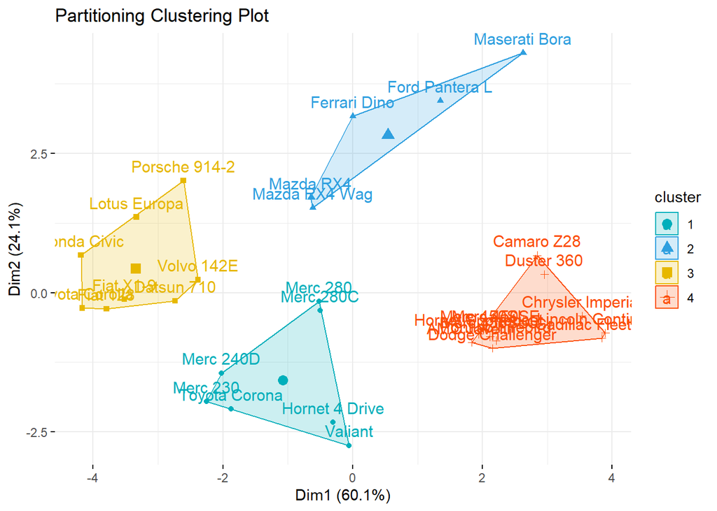

```r
 fviz_cluster(km.res, data = df,
             palette = c("#00AFBB","#2E9FDF", "#E7B800", "#FC4E07"),
             ggtheme = theme_minimal(),
             main = "Partitioning Clustering Plot"
             )
```

```r
library(cluster)
library(HSAUR)
## Warning: package 'HSAUR' was built under R version 3.3.3
## Loading required package: tools
```

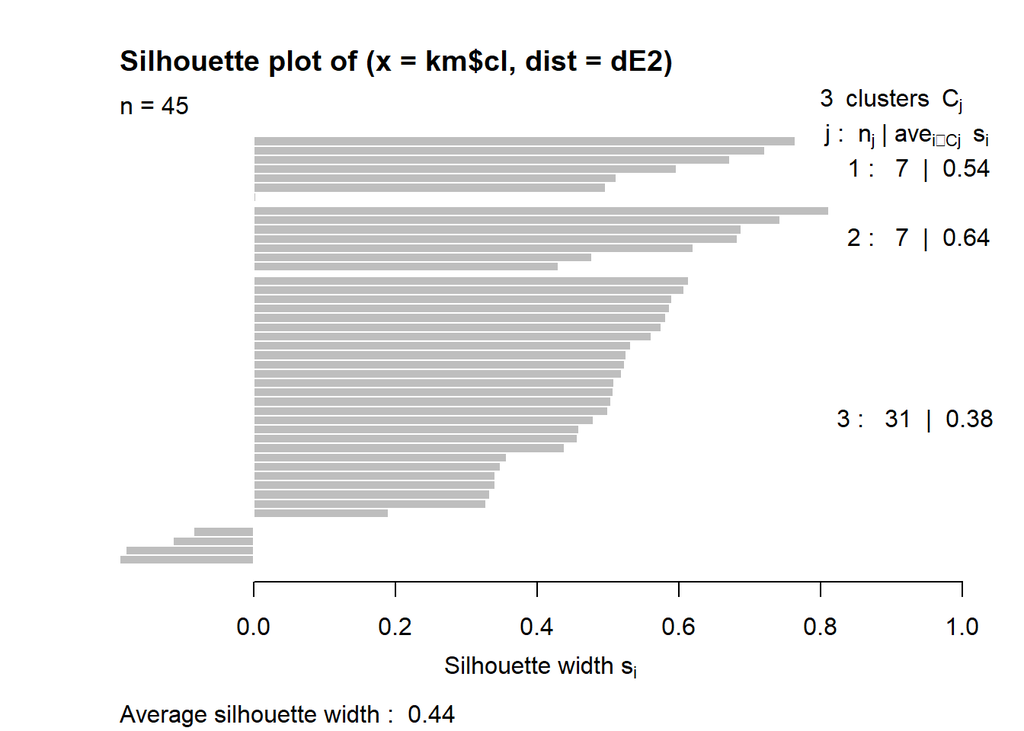

```r
data(pottery)
km    <- kmeans(pottery,3)
dissE <- daisy(pottery)
dE2   <- dissE^2
sk2   <- silhouette(km$cl, dE2)
plot(sk2)
```

# Referensi

1). https://rpubs.com/JanpuHou/278558

2). https://github.com/nasrullaili34/ALGORITMA-KMEANS

3). https://medium.com/@16611094/clustering-menggunakan-metode-k-means-cluster-di-r-80827b4a48fd

4). https://medium.com/@salsabillanovia/k-means-clustering-mtcars-dataset-with-r-e6ee485ecdad